# Exploring Vancouver Crime Data with R

Tucker Doud

Nov 10, 2014

## Introduction

This report was written simply because I wanted to get some practice authoring literate statistical programming reports using [R Markdown](http://rmarkdown.rstudio.com/). R Markdown is a basic language used to author web pages which allows analysts to embed computations and visualizations from the [R Statistical Programming Language](http://www.r-project.org/) within an HTML document. Literate Programming allows the reader to get a plain language version of a data analysis woven together with the actual source code used to produce the statistics and visualizations. Using the code, the reader is empowered to completely reproduce the analytical work thus ensuring openness and integration between analytical thought and presentation.

For this example I examine some crime data posted on the City of Vancouver [Open Data Catalogue](http://vancouver.ca/your-government/open-data-catalogue.aspx). I take the reader through some exploratory data analysis and visualization using R.

## Set up the Analysis

One of the benefits of R being a completely open source program is that it allows for a very wide networks of developers to to write add ons for the program. For this piece I use two of such tools for data analysis and visualization: `dplyr` for data manipulation and `ggplot2` for visualization. These tools are loaded below.

```r
# Load Required Libraries
library(dplyr)
library(ggplot2)
```

Rather than using my web browser to get the data source from the Vancouver open data portal I can have R do it for me and save the data into my analysis file. I obtain the data file for the most recent *complete* year at the time of this writing. The following code downloads the data, saves it into my working directory.

```r
# Get data
download.file(url = "ftp://webftp.vancouver.ca/opendata/csv/crime_2013.csv", destfile = "./crime_2013.csv")
```

Now I can read the data into R. I leave any character type variables as text strings (rather than having R convert them to categorical variables) because I want to have control over the process later on.

```r
# Read in data
data <- read.csv("./crime_2013.csv", stringsAsFactors = F)
```

## Exploratory Data Analysis

Now that we have our data we can use some base R functions to explore the data a little.

```r
# Explore variable names
names(data)
```

```
## [1] "TYPE"          "YEAR"          "MONTH"         "HUNDRED_BLOCK"
```

```r
# Change names to lower case
names(data) <- tolower(names(data))
```

The data file contains 4 variables noted above. Since R programming is predominantly done in lower case I convert the variable names to lower case to make my coding more consistent.

Next I explore the size and structure of the data file.

```r
# Review structure
str(data)
```

```
## 'data.frame':    15335 obs. of  4 variables:
##  $ type         : chr  "Commercial Break and Enter" "Commercial Break and Enter" "Commercial Break and Enter" "Commercial Break and Enter" ...
##  $ year         : int  2013 2013 2013 2013 2013 2013 2013 2013 2013 2013 ...
##  $ month        : int  1 1 1 1 1 1 1 1 1 1 ...
##  $ hundred_block: chr  "10XX CAMBIE ST" "6XX THURLOW ST" "9XX ROBSON ST" "5XX W BROADWAY AVE" ...
```

The data file contains 15335 observations and 4 variables (noted above). The `year` and `month` variables are integers. The `type` and `hundred_block` are character variables (left in that form from the step above).

I can use the `head` function in R to show me the top 10 rows of the data file to give me a bit more information.

```r
# Examine first 10 rows
head(data, 10)
```

```
##                          type year month      hundred_block
## 1  Commercial Break and Enter 2013     1     10XX CAMBIE ST
## 2  Commercial Break and Enter 2013     1     6XX THURLOW ST
## 3  Commercial Break and Enter 2013     1      9XX ROBSON ST
## 4  Commercial Break and Enter 2013     1 5XX W BROADWAY AVE
## 5  Commercial Break and Enter 2013     1   10XX W PENDER ST
## 6  Commercial Break and Enter 2013     1     12XX W 6TH AVE
## 7  Commercial Break and Enter 2013     1   10XX MAINLAND ST
## 8  Commercial Break and Enter 2013     1      8XX QUEBEC ST
## 9  Commercial Break and Enter 2013     1   10XX MAINLAND ST
## 10 Commercial Break and Enter 2013     1  1XX E HASTINGS ST
```

Or for a more representative example I can take a random sample of 10 rows to display.

```r
# Review a random sample of rows
data[sample(x = nrow(data), size = 10), ]
```

```
##                              type year month         hundred_block
## 4057  Theft From Auto Under $5000 2013     4        31XX E 5TH AVE
## 468   Theft From Auto Under $5000 2013     1    6XX W BROADWAY AVE
## 793   Theft From Auto Under $5000 2013     1 22XX PRINCE ALBERT ST
## 1380         Mischief Under $5000 2013     2     5XX E HASTINGS ST
## 15013 Theft From Auto Under $5000 2013    12        42XX FRASER ST
## 6128   Commercial Break and Enter 2013     6       12XX W 10TH AVE
## 8210  Theft From Auto Under $5000 2013     7        6XX BURRARD ST
## 6427         Mischief Under $5000 2013     6      29XX E PENDER ST
## 1932  Theft From Auto Under $5000 2013     2    47XX COMMERCIAL ST
## 3584   Commercial Break and Enter 2013     4    14XX OLD BRIDGE ST
```

Since I only downloaded data for 2013 I make sure that the data file only contains incidents for the correct year. Furthermore, I determine that the file contains data for all 12 months.

```r
# Check year
unique(data$year)
```

```
## [1] 2013
```

```r
# Make sure month variable is as expected
unique(data$month)
```

```
##  [1]  1  2  3  4  5  6  7  8  9 10 11 12
```

As we can see, we only have data for the year 2013 and all 12 months are covered.

Let us have a closer look at the `type` variable.

```r
# View unique categories of crime type
unique(data$type)
```

```
## [1] "Commercial Break and Enter"  "Mischief Over $5000"
## [3] "Mischief Under $5000"        "Theft From Auto Over  $5000"
## [5] "Theft From Auto Under $5000" "Theft Of Auto Over $5000"
## [7] "Theft Of Auto Under $5000"
```

We have 7 types of crime reported in this data file. It appears that only property crimes are included. Now I convert this variable to a categorical type so R can make better use of it in later stages of this analysis. I use the `factor` function to convert the variable. Then I use the `reorder` function to rearrange the levels of the categories based on how many observations each level account for. This will come in handy later on.

```r
# Convert type to factor
data$type <- factor(x = data$type)
data$type <- reorder(x = data$type, X = data$type, FUN = length)
```

Next I convert the `month` variable to an ordered factor with names for each of the months. This will make the visualizations easier to read later on. I add this to a new variable called `monthRC` - for month *recoded* - just in case I need to keep the integer format for another purpose later on.

```r
data$monthRC <- factor(x = data$month,
                        labels = c("Jan", "Feb", "Mar", "Apr", "May", "Jun",
                                   "Jul" ,"Aug" ,"Sep" , "Oct", "Nov", "Dec"),
                        ordered = T)
```

Now that I have tidied up the data file, I can do a little number crunching.

But first I check to see if there are any observations with missing data.

```r
# Any missing?
sum(!complete.cases(data))
```

```
## [1] 0
```

Zero incomplete observations.

I begin the analysis by tallying the observations by the `type` variable using base R’s `table` function.

```r
# Tally by type
table(data$type)[order(table(data$type), decreasing = T)] # Order decreasing
```

```
##
## Theft From Auto Under $5000        Mischief Under $5000
##                        8199                        4128
##  Commercial Break and Enter   Theft Of Auto Under $5000
##                        1778                         803
##    Theft Of Auto Over $5000 Theft From Auto Over  $5000
##                         229                         147
##         Mischief Over $5000
##                          51
```

We can see that **Theft From Auto Under $5000** was the most frequent type of crime in 2013. **Mischief Over $5000** was the least frequent.

Next I have a look at the frequency of crimes by *month*. But I don’t like the way the `table` function displays information so I will use `dplyr` (mentioned above), which provides nicer output and uses a far more legible syntax.

```r
# Tally by month the dplyr way
group_by(.data = data, monthRC) %>%
    summarise(count = n()) %>%
    arrange(desc(count))
```

```
## Source: local data frame [12 x 2]
##
##    monthRC count
## 1      Nov  1475
## 2      Oct  1415
## 3      Dec  1373
## 4      Apr  1352
## 5      Mar  1351
## 6      May  1339
## 7      Jul  1280
## 8      Jun  1231
## 9      Sep  1227
## 10     Aug  1213
## 11     Feb  1041
## 12     Jan  1038
```

## Visualizations

Tables are a nice way to summarize data but since humans tend to be better at recognizing visual patterns, I plot the same data with a bar chart. The default plotting in ggplot2 is nice but I prefer a more simplified look for presenting data on the web. I set up a custom ggplot theme with the code below and then plot the data.

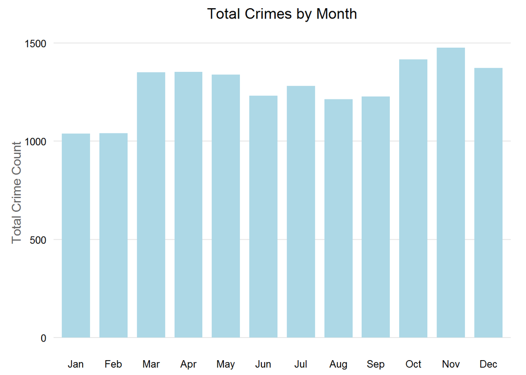

```r
# Set up custom theme
my_theme <- theme_bw() +
    theme(panel.border = element_blank(),
          axis.ticks = element_blank(),
          panel.grid.minor = element_blank(),
          panel.grid.major.x = element_blank(),
          panel.grid.major.y = element_line(size = 0.5),
          axis.title = element_text(colour = "grey40"),
          plot.title = element_text(vjust = 2.0))

# Plot crime count by month
ggplot(data = data, aes(x = monthRC)) +
    my_theme +
    geom_bar(stat = "bin", fill = "lightblue", width = 0.75) +
    ggtitle("Total Crimes by Month") +
    xlab(NULL) +
    ylab("Total Crime Count")
```

The visualization makes it easier to see that total crimes *generally* increase throughout the year.

The chart above helps to do some interpretation but since we have the crime *type* in the data, why not plot the different types over time. I’ll divide it into two plots so the less frequent crimes do not get crammed down at the bottom of the plot.

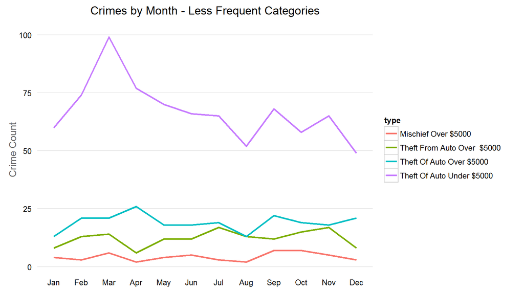

```r
# Subset the data for the less frequent categories
sub <- levels(data$type)[1:4] # Create a subseting object
temp <- filter(.data = data, type %in% sub) # Subset using dplyr

# Make plot
ggplot(data = temp, aes(x = monthRC, color = type, group = type)) +
    my_theme +
    geom_line(stat = "bin", size = 1) +
    ggtitle("Crimes by Month - Less Frequent Categories") +
    xlab(NULL) +
    ylab("Crime Count")
```

Notice the spike in *Theft of Auto Under $5000* in March. The other categories are fairly consistent throughout the year at less than 25 occurrences per month.

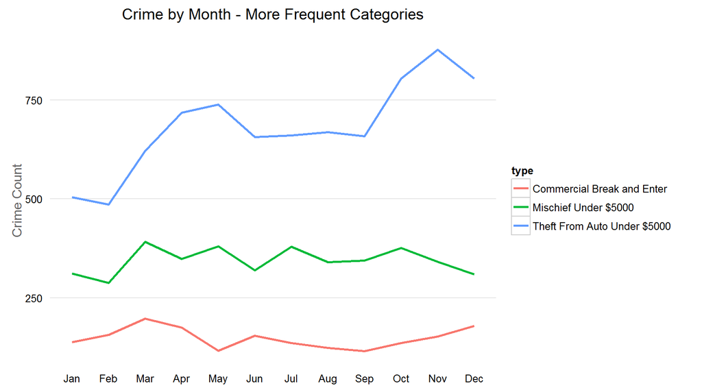

```r
# Do another subset for the more frequent categories
sub <- levels(data$type)[5:7]
temp <- filter(.data = data, type %in% sub)

# Make second plot
ggplot(data = temp, aes(x = monthRC, color = type, group = type)) +
    my_theme +
    geom_line(stat = "bin", size = 1) +
    ggtitle("Crime by Month - More Frequent Categories") +
    xlab(NULL) +
    ylab("Crime Count")
```

Here we can see that *Theft from Auto Under $5000* is what is driving the general increase in crimes we detected in the first plot.

## Summary

And there we have some data exploration and visualization using the R programming language! As mentioned above, the reader also has full access to the code to reproduce this analysis on their own.

Finally, as you may have noticed, I made no use of what may be the most interesting variable in the data file… Recall from above that all of the crimes have been coded with a location in the `hundred_block` variable. R can also be used to do spatial analysis and mapping using location data. As a follow up to this report I will issue a part two that makes use of the location information for mapping.